# Clase 03 - Guía Análisis exploratorio de datos

DBT 845 - Investigación reproducible y análisis de datos biotecnológicos con R.

Dr. José A. Gallardo y Dra. María Angélica Rueda.

Pontificia Universidad Católica de Valparaíso  
jose.gallardo@pucv.cl

28 March 2022

## **Introducción**

Los análisis exploratorios de datos son procedimientos que usan los estadísticos para visualizar y explorar los datos de un estudio. Esto les permite investigar la calidad y limpiar los datos previo a la realización de las pruebas estadísticas. Un buen análisis exploratorio de datos permite observar la variación y covariación de los datos, así como establecer modelos básicos de relación e interacción entre las variables bajo estudio.

En los análisis exploratorio de datos el investigador debe iterar entre la generación de algunas preguntas iniciales para explorar sus datos y la visualicación, transformación y modelamiento de sus datos, para luego, usar lo aprendido y volver a generar nuevas preguntas hasta alcanzar un nivel de comprención avanzada de sus datos [**Fuente: R for Data Science**](https://r4ds.had.co.nz/exploratory-data-analysis.html).

## **Objetivos de aprendizaje**

Los objetivos de aprendizaje de esta guía son:

**1**. - Realizar un análisis exploratorio de datos.

**2**. - Realizar gráficas avanzadas con ggplot2.

## **Librerías**

**readxl**: Permite importar datos a partir de archivos con formato **.xls** y **.xlsx**

**ggplot2**: Librería de visualización de datos preferido para realizar graficas avanzadas con R [ggplot2 book](https://ggplot2-book.org//)).

**psych**: Librería con un comando simple para realizar histogramas y correlaciones de datos en formato de matriz.

## **Comandos**

A continuación, se presentan algunos comandos que podrían ser usados para resolver los ejercicios de esta guía. Otros, los usará más adelante en el curso y los deberá investigarlos por su propia cuenta.

**1.-** Realiza una gráfica para observar la interacción de 2 factores sobre una variable respuesta con esta función de la libraría **stats**: **interaction.plot()**.

**2.-** Investiga el efecto de uno o más factores sobre una variable respuesta con esta función de la librería **graphics**: **plot.design()**.

**3.-** Explora la distribución de frecuencia y correlación de muchas variables continuas con esta función de la librería **psych**: **pairs.panels**.

**4.-** Visualiza la variación de tus datos de forma avanzada con ggplot2. Si das los primeros pasos en ggplot2 te sugerimos revisar este capítulo del autor de la librería [Getting started](https://ggplot2-book.org/getting-started.html).

Comparación de algunos comandos de gráficas entre la librería **graphics** y **ggplot2**

| Función | graphics | ggplot2 |
| --- | --- | --- |
| Función genérica para graficar | plot() | ggplot() |
| Histogramas | hist() | geom_histogram() |
| Gráfica de cajas y bigotes | boxplot() | geom_boxplot() |
| Etiquetar ejes | xlab=“” , ylab=“” | labs(x=““, y=”“) |

## **Ejercicios**

### **Ejercicio 1.** Elaborar un Script de R (Archivo .R)

Elabore un archivo o file con extensión **.R** usando la barra de herramientas de **Rstudio**. Selecciona **File > New file > R script**. Utilice el siguiente ejemplo para completar la información de **metadatos** del script.

```
# ----------------------------------------------------------
# Clase 3 - Script Análisis exploratorio de datos.
# Su nombre.
# Fecha de hoy.
# DBT 845 - Investigación reproducible y análisis de datos biotecnológicos con R.
# ----------------------------------------------------------
```

Luego, guarde inmediatamente su script como **script_EDA_nombre_apellido.R**.

### **Ejercicio 2.** Configuración del Script

Cargue las librerías **stats**, **graphics**, **ggplot2**, **psych** y **readxl** usando la función **library()**.

### **Ejercicio 3.** Explorar y visualizar variación de los datos con un histograma

**a)** Elabore un objeto denominado “datos” e importe el set de datos **animal.xslx** usando la función **read_excel()** de la librería **readxl**. Observe los datos con la función **summary()** y **str**. Note que las variables **animal_id** y **genotype** están codificadas como **character** y el **weight** como **numeric**

```
##   animal_id           genotype             weight
##  Length:100         Length:100         Min.   : 752.2
##  Class :character   Class :character   1st Qu.:2916.6
##  Mode  :character   Mode  :character   Median :4141.6
##                                        Mean   :4562.6
##                                        3rd Qu.:6104.6
##                                        Max.   :9121.1
```

```
## tibble [100 × 3] (S3: tbl_df/tbl/data.frame)
##  $ animal_id: chr [1:100] "id_1" "id_2" "id_3" "id_4" ...
##  $ genotype : chr [1:100] "AA" "AC" "AA" "AC" ...
##  $ weight   : num [1:100] 2518 5205 3821 6601 8698 ...
```

**b)** Transforme las variables **animal_id** y **genotype** a factor usando la función **as.factor()**. Luego, explore nuevamente el set de datos usando la función **summary()**. Finalmente, explore la variable **genotype** con la función **table()**. Pruebe explorar la variable continua weight con la función **table()** y discuta con sus compañeros porqué esto **no es adecuado**.

```
##    animal_id  genotype     weight
##  id_1   : 1   AA:53    Min.   : 752.2
##  id_10  : 1   AC:41    1st Qu.:2916.6
##  id_100 : 1   CC: 6    Median :4141.6
##  id_11  : 1            Mean   :4562.6
##  id_12  : 1            3rd Qu.:6104.6
##  id_13  : 1            Max.   :9121.1
##  (Other):94
```

```
##
## AA AC CC
## 53 41  6
```

**c)** A partir de su set de datos elabore una gráfica para la variable continua **weight**. Use el comando **ggplot()**, el argumento **aes()** para seleccionar los datos, y la variable respuesta **weight**. Con el simbolo **+** agregue el comando **geom_histogram()** para obtener un histograma.

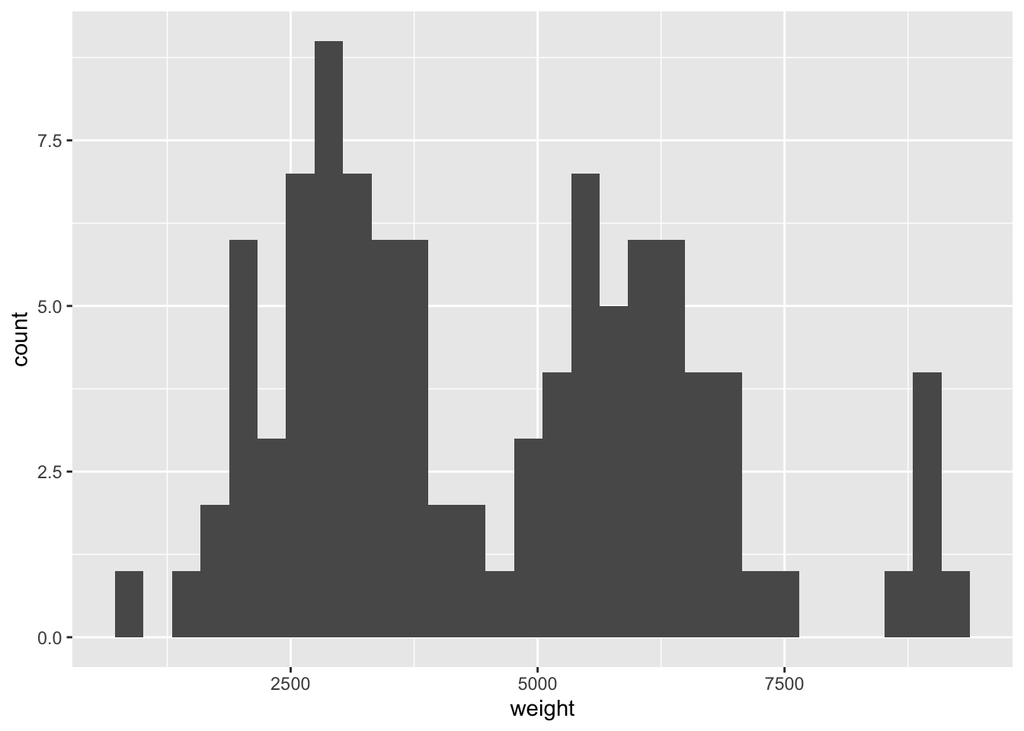

```r
ggplot(datos, aes(x = weight)) +
  geom_histogram()
```

**d)** Para distinguir los diferentes niveles del factor **genotype** en el histograma, incluya dentro del comando **geom_histogram()** el argumento **aes(color = genotype)**.

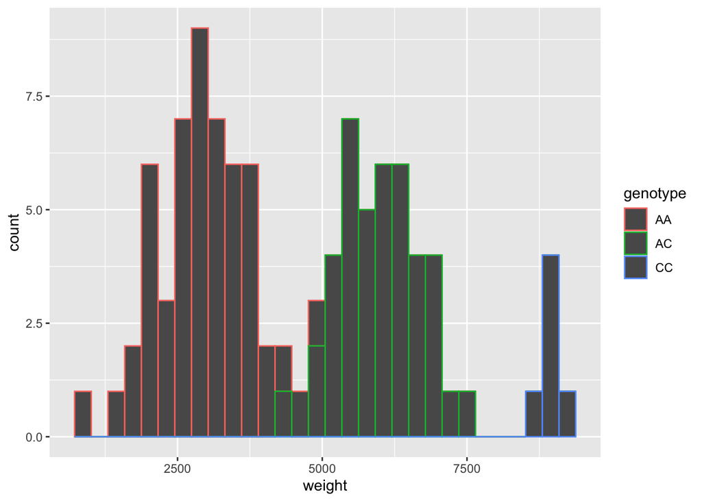

**e)** Con el objetivo de visualizar de mejor forma los datos incluya dentro del comando **ggplot** y “después de una ,” la siguiente línea de código **position = “identity”, bins = 20, alpha = 0.4** . Modifique los valores de **bins** y **alpha** por otros números y observe como cambia la estética del gráfico. Seleccione un valor que permita una buena visualización de la distribución de cada nivel dentro de genotype.

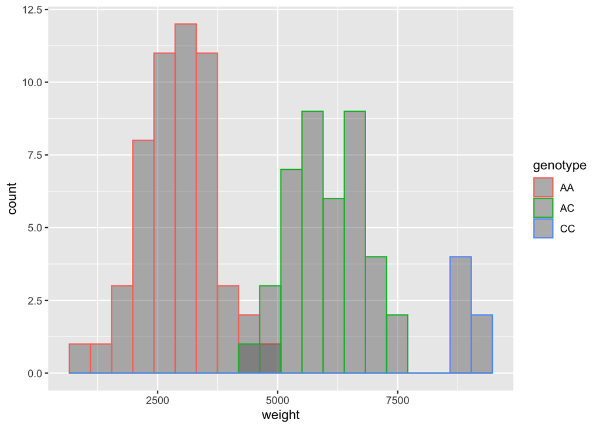

**f)** Grafique la distribución acumulada empírica de la variable **weight** usando el comando **plot(ecdf())** y compare con el histograma anterior. ¿Es posible deducir a partir de la densidad empírica la distribución de frecuencia de los datos?

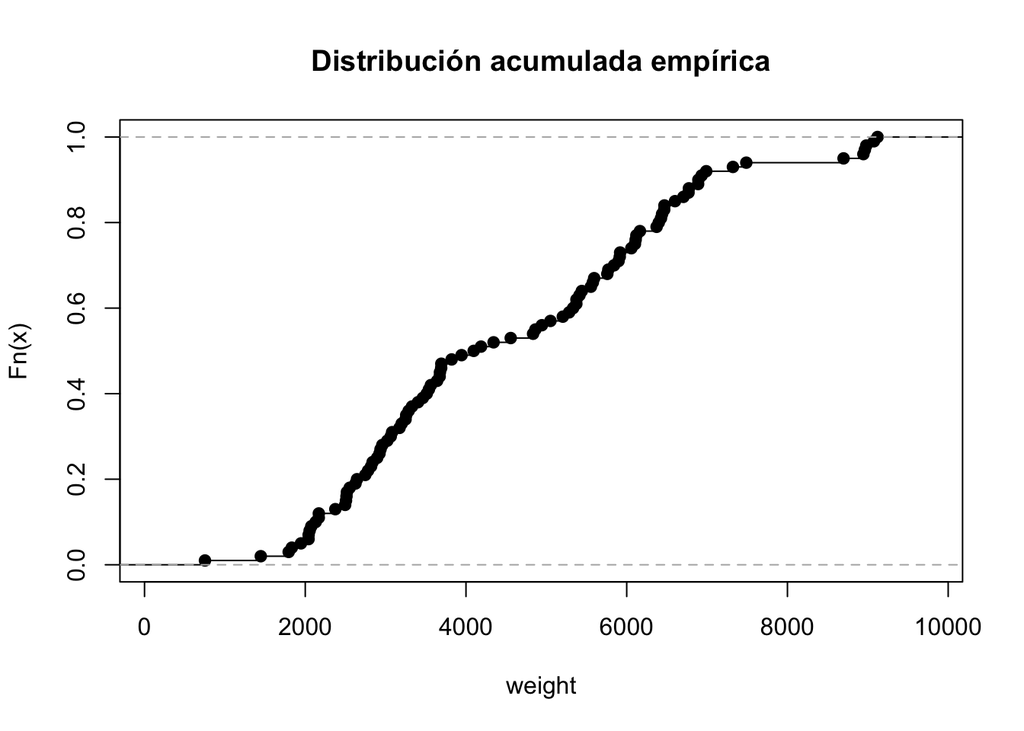

### **Ejercicio 5.** Explorar y visualizar variación de los datos con un boxplot.

**a)** A partir del set de datos anterior elabore una gráfica de cajas y bigotes para la variable **weight**. Use el comando **ggplot()** y el argumento **aes(x,y)** para seleccionar los datos, donde x será la variable de clasificación **genotype** e y será la variable respuesta **weight**. Con el simbolo **+** agregue el comando **geom_boxplot()** para obtener un boxplot.

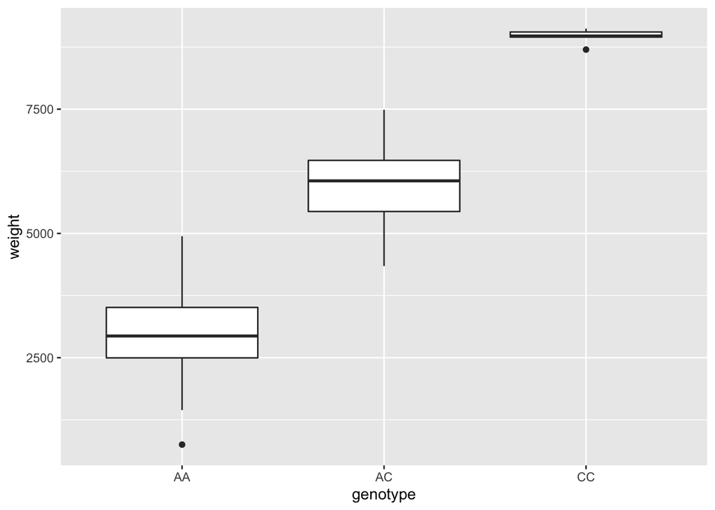

```r
ggplot(datos, aes(x=genotype, y=weight)) +
    geom_boxplot()
```

**b)** Para distinguir de mejor forma los diferentes niveles del factor **genotype** en el boxplot incluya dentro del argumento **aes()** el siguiente parámetro **fill = genotype**.

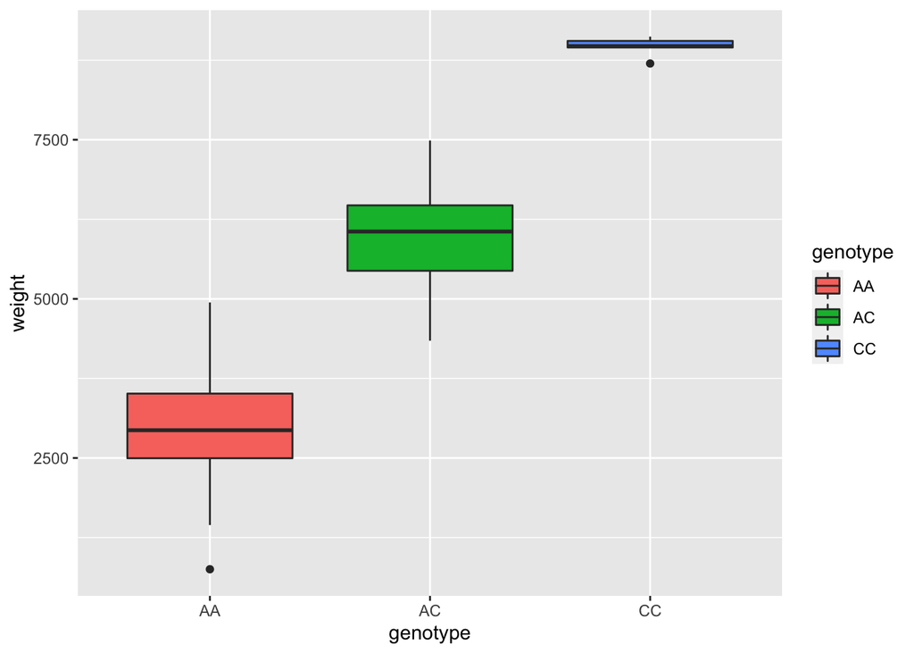

**c)** Use el comando **labs()** para incluir la etiqueta del eje y “Peso de cosecha (g)”

[figure not shown]

**d)** agregue a al código anterior el comando **geom_jitter()** para visualizar todos los datos de “weight”

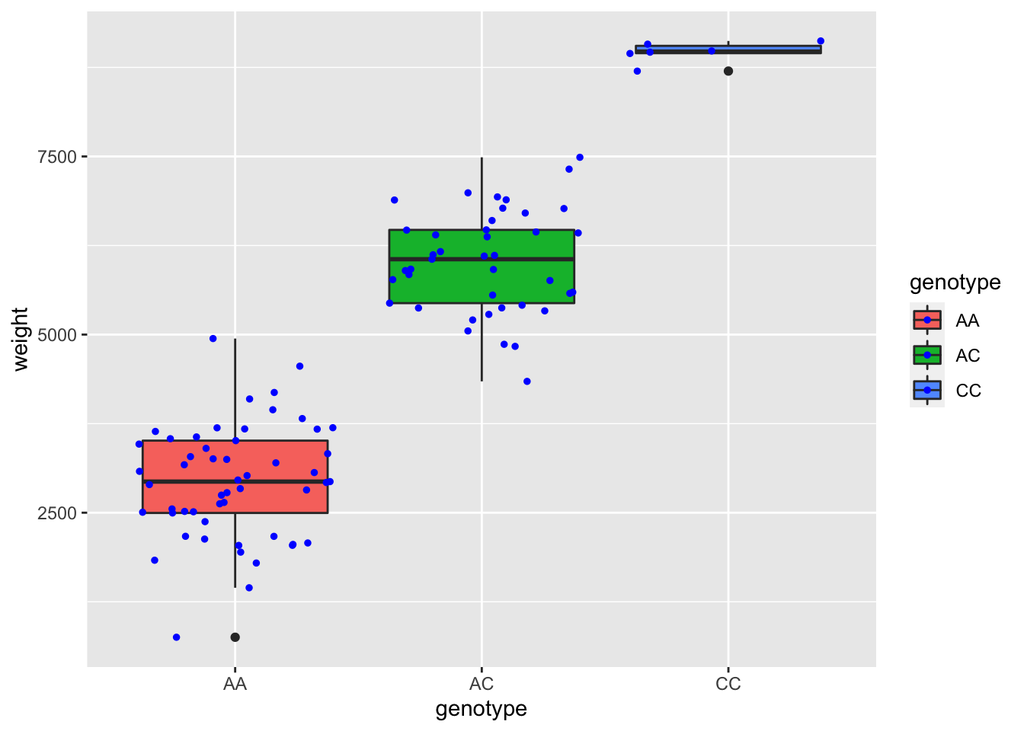

### **Ejercicio 6.** Explorar y visualizar la interacción de dos factores

**a)** Importe el set de datos **mouse.xslx** usando la función **read_excel()** de la librería **readxl**.

Transforme a factor las columnas **animal_id**, **feed** y **sex** con la función **as.factor()**. Luego, explore el set de datos usando la función **summary()** y explore los factores **feed** y **sex** con la función **table()**. Pruebe explorar la variable **animal_id** con la función **table()** y discuta con sus compañeros porqué **esto no es adecuado**.

```
##        id     feed        sex         weight
##  id_1   : 1   d1:12   Hembra:54   Min.   :10.30
##  id_10  : 1   d2:10   Macho :17   1st Qu.:20.45
##  id_11  : 1   d3:12               Median :25.90
##  id_12  : 1   d4:11               Mean   :26.11
##  id_13  : 1   d5:14               3rd Qu.:32.55
##  id_14  : 1   d6:12               Max.   :41.80
##  (Other):65
```

```
##
##      Hembra Macho
##   d1      9     3
##   d2      7     3
##   d3      8     4
##   d4      9     2
##   d5     11     3
##   d6     10     2
```

**b)** A partir del set de datos de mouse elabore una gráfica de cajas y bigotes para la variable **weight**. Use el comando **ggplot()** y el argumento **aes(x,y,fill)** para seleccionar los datos, el factor **feed**, la variable respuesta **weight** y el 2do factor **sex**. Agregue el comando **geom_boxplot()** para obtener el boxplot.

¿Observa algún patrón claro de interacción entre sex y feed?

¿Cuál de los dos factores tiene mayor influencia en la variable respuesta?

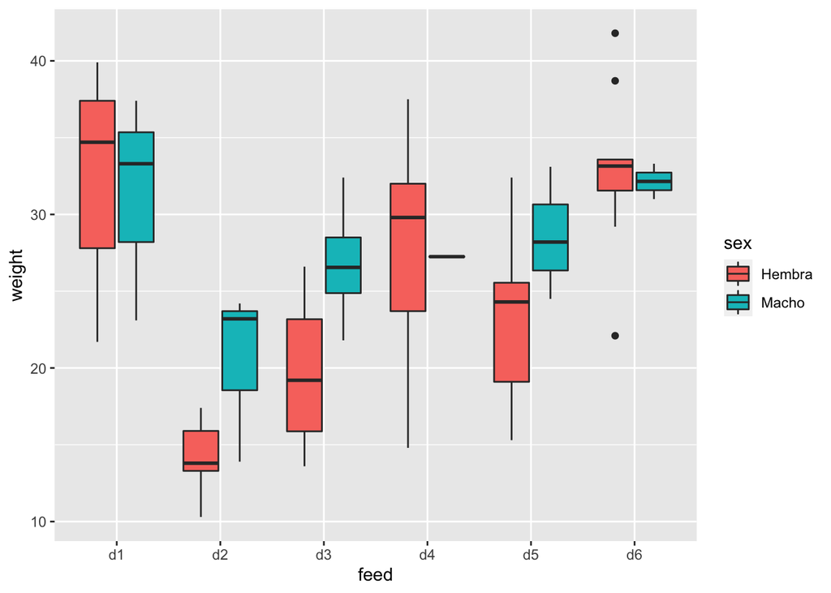

```r
ggplot(mouse, aes(x=feed, y=weight, fill=sex)) +
    geom_boxplot()+
  labs(y="weight")
```

**c)** Realice ahora una gráfica de interacción y una gráfica de tamaño de los efectos de la variable *weight* usando las funcines **interaction.plot()** y **plot.design()**. Incluya *feed* y *sex* como factores.

La forma correcta de escribir el modelo de interacción es el siguiente:

**interaction.plot(objeto$factorA, objeto%factorB, objeto$variableRespuesta, fun=c(mean, median))**

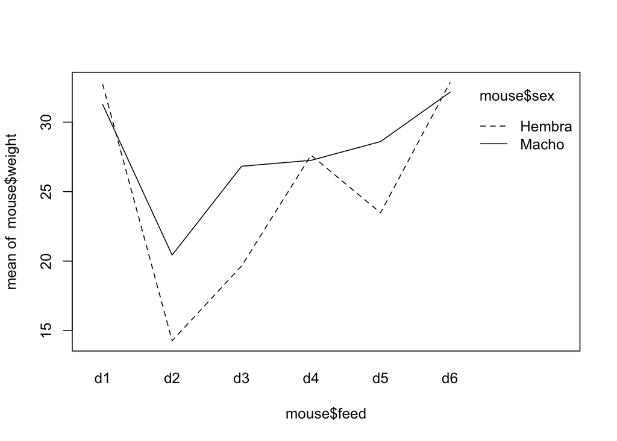

**d)** Ahora mejore la visualización del gráfico de interacción mediante la inclusión del nombre de los ejes **(xlab=““, ylab”“)**, un color para cada tratamiento **col=**, agregar simbolos a cada valor promedio **pch=** e mediante la inclusión tanto de una línea como de un punto con el argumento **type=b**.

Responda: ¿Existe interación entre los factores sex y feed?

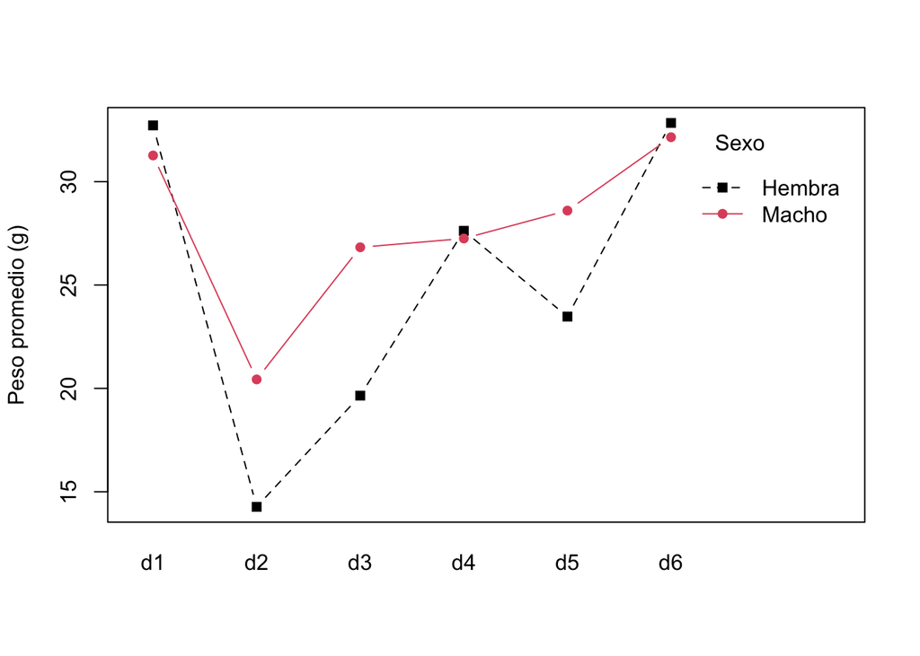

**d)** Realice ahora una grafica de tamaño de los efectos de la variable **weight** usando la función **plot.design()**. Incluya **feed** y **sex** como factores.

La forma correcta de escribir el modelo de interacción es el siguiente:

**plot.design(respuesta ~ factor a, factor b)**

el simbolo **~** se lee modelado por o explicado por.

Incluya etiquetas en el eje x e y, de un color a su gráfica con el comando **col=**

Responda: ¿Qué factor tiene una mayor influencia en la variable respuesta weight?

[figure not shown]

### **Ejercicio 7.** Explorar y visualizar covariación de variables continuas.

El archivo **“Muscle.xlsx”** contiene un extracto del registro original de datos de masa muscular y masa de huesos de 29 ratones de laboratorio sometidos a un experimento conductual. Cooper et al. 2020

**a)** Importe el set de datos **Muscle.xslx** usando la función **read_excel()** de la librería **readxl**. Explore el set de datos completo con la función **summary()**. Transforme a factor la variable ID y status.

```
##        ID        status     body mass         skull           mandible
##  c1012  : 1   loser :20   Min.   :17.30   Min.   :0.1543   Min.   :0.06210
##  c1013  : 1   winner: 9   1st Qu.:20.90   1st Qu.:0.1777   1st Qu.:0.06840
##  c1015  : 1               Median :22.40   Median :0.1891   Median :0.07385
##  c1030  : 1               Mean   :22.41   Mean   :0.1897   Mean   :0.07318
##  c1038  : 1               3rd Qu.:23.80   3rd Qu.:0.2019   3rd Qu.:0.07723
##  c1061  : 1               Max.   :27.90   Max.   :0.2172   Max.   :0.08340
##  (Other):23                               NA's   :2        NA's   :1
##     humerus            radius             pelvis            femur
##  Min.   :0.01340   Min.   :0.004600   Min.   :0.03440   Min.   :0.02510
##  1st Qu.:0.01560   1st Qu.:0.005200   1st Qu.:0.03807   1st Qu.:0.02890
##  Median :0.01650   Median :0.005750   Median :0.04140   Median :0.03080
##  Mean   :0.01693   Mean   :0.005605   Mean   :0.04186   Mean   :0.03166
##  3rd Qu.:0.01860   3rd Qu.:0.006075   3rd Qu.:0.04615   3rd Qu.:0.03410
##  Max.   :0.02070   Max.   :0.006300   Max.   :0.04950   Max.   :0.04090
##                    NA's   :7          NA's   :1
##   total_bones          pecs             neck              biceps
##  Min.   :0.3492   Min.   :0.0161   Min.   :0.004600   Min.   :0.006900
##  1st Qu.:0.3734   1st Qu.:0.0231   1st Qu.:0.006800   1st Qu.:0.008100
##  Median :0.4040   Median :0.0262   Median :0.007500   Median :0.009800
##  Mean   :0.3985   Mean   :0.0282   Mean   :0.007703   Mean   :0.009862
##  3rd Qu.:0.4260   3rd Qu.:0.0317   3rd Qu.:0.008500   3rd Qu.:0.010900
##  Max.   :0.4411   Max.   :0.0495   Max.   :0.014100   Max.   :0.014900
##  NA's   :9
##     triceps            glutes         total_muscle
##  Min.   :0.01950   Min.   :0.02270   Min.   :0.2129
##  1st Qu.:0.02910   1st Qu.:0.03360   1st Qu.:0.2544
##  Median :0.03180   Median :0.03960   Median :0.3033
##  Mean   :0.03217   Mean   :0.03807   Mean   :0.2995
##  3rd Qu.:0.03640   3rd Qu.:0.04390   3rd Qu.:0.3282
##  Max.   :0.04340   Max.   :0.04680   Max.   :0.4042
##
```

**b)** Investigue la función **pairs.panels()** de la librería **psych**. Use esta función para obtener histogramas, gráficas de densidad (density = TRUE) y correlación (method = “pearson”) de todas las variables del set de datos. Cómo el número de variables es muy grande se recomienda imprimir algunas correlaciones a la vez, por ejemple muscle[,1:5] imprimirá las correlaciones entre las primeras 5 variables.

Responda: ¿Por qué no es adecuado incluir en este análisis de correlación la variable id y la variable status?

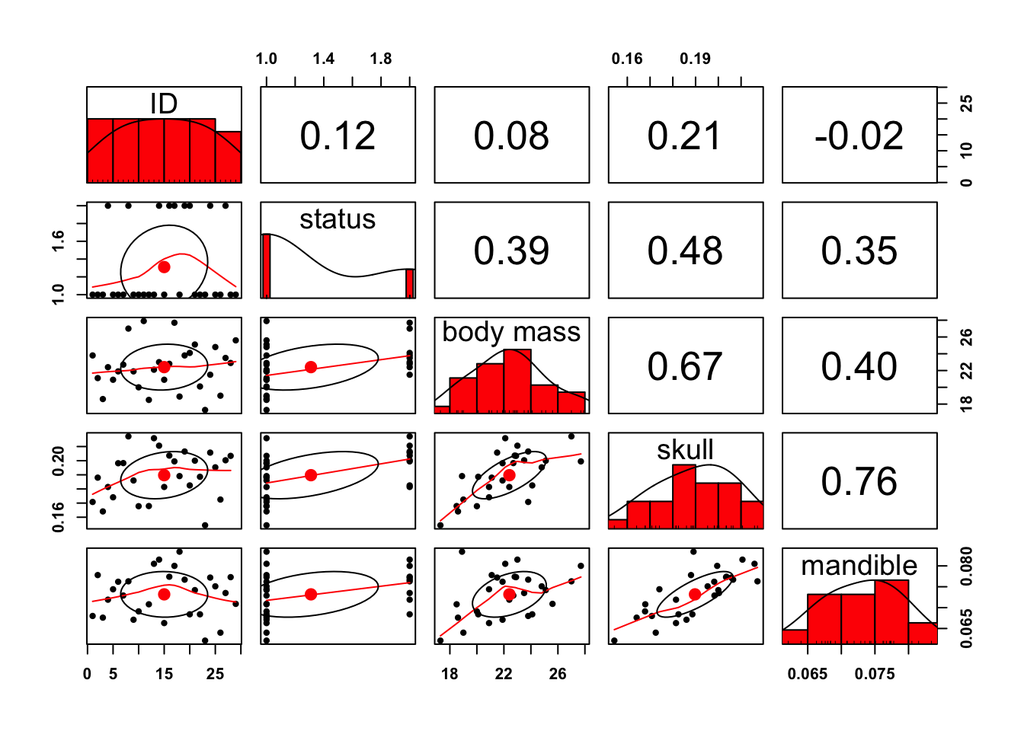

Correlación entre las primeras 5 variables

```r
# Gráfica de correlación de variables continuas
pairs.panels(muscle[,1:5], method = "pearson", hist.col = "red",  density = TRUE, font=2)
```

**c)** Elimine la variable **id** y la variable **status** del análisis anterior seleccionando las columnas 3 y 8 (muscle[,3:8]) y responda:

¿Qué variables son las mas correlacionadas?

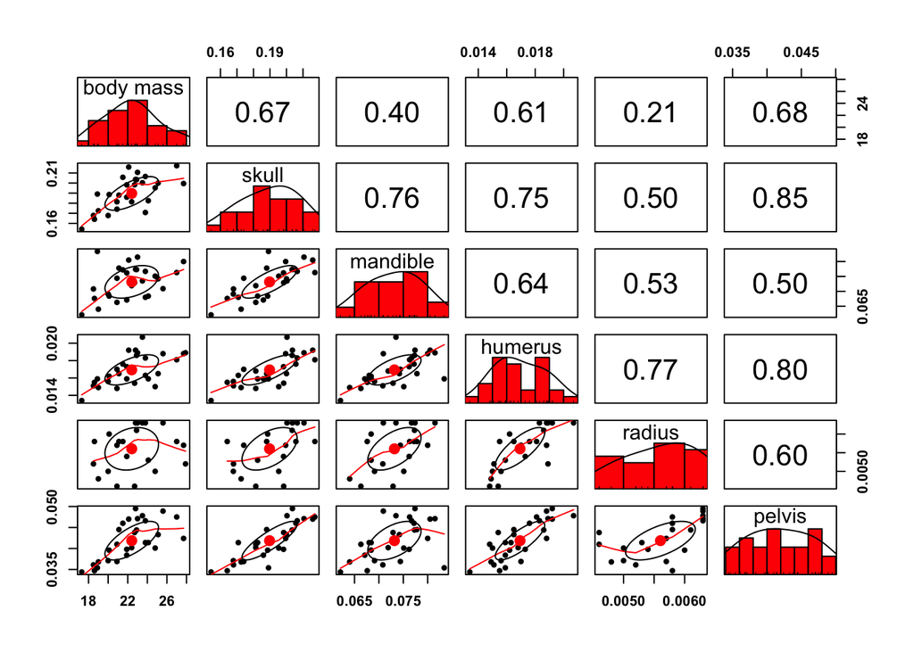